# R Notebook

| Title: “IST687 – Text Mining HW” |
| --- |
| Name: Sathish Kumar Rajendiran |
| Week: 8 |
| Date: 05/27/2020 |

Exercise: Text Mining HW

# Install necessary packages

```r
install.packages( pkgs=c("gdata","RCurl","ggplot2","ggcorrplot","reshape2","ggeasy","viridis","viridisLite"),repos = "http://cran.us.r-project.org")
```

[output not shown]

```r
library(gdata)
library(RCurl)
library(ggplot2)
library(ggcorrplot)
library(reshape2)
library(ggeasy)
library(viridis)
library(viridisLite)
```

#printDataInfo function

```r
# function printDataInfo
  printDataInfo <- function(myData)
    {
      strinfo <- str(myData)
      cat("str:",strinfo,"\n")

      colnamesinfo <- colnames(myData)
      cat("colnames:",colnamesinfo,"\n")

      diminfo <- dim(myData)
      cat("dim:",diminfo,"\n")

      nrowinfo <- nrow(myData)
      cat("nrow:",nrowinfo,"\n")

      nrowsinfo <- myData[1:5,]
      return(nrowsinfo)
     }
```

#1. Read in data from the following URL:

1. Read in data from the following URL:If you view this in a spreadsheet, you will find that four columns of a small dataset. The first column shows the number of fawn in a given spring (fawn are baby Antelope). The second column shows the population of adult antelope, the third shows the annual precipitation that year, and finally, the last column shows how bad the winter was during that year.
2. You have the option of saving the file save this file to your computer and read it into R, or reading the data directly from the web into a data frame.
3. You should inspect the data using the str() command to make sure that all of the cases have been read in (n=8 years of observations) and that there are four variables.

```r
# filepath

    filepath <- "http://college.cengage.com/mathematics/brase/understandable_statistics/7e/students/datasets/mlr/excel/mlr01.xls"

     # function readFiles
     readFiles <- function(fpath)
        {
        dftemp <- read.xls(filepath)
        return(dftemp)
      }


    #Import the data into temporary datasets

    mlrdf <- data.frame(readFiles(filepath),stringsAsFactors = FALSE)
    mlrdf[1:3]
```

| X1 | X2 | X3 |
| --- | --- | --- |
| 2.9 | 9.2 | 13.2 |
| 2.4 | 8.7 | 11.5 |
| 2.0 | 7.2 | 10.8 |
| 2.3 | 8.5 | 12.3 |
| 3.2 | 9.6 | 12.6 |
| 1.9 | 6.8 | 10.6 |
| 3.4 | 9.7 | 14.1 |
| 2.1 | 7.9 | 11.2 |

```r
    colnames(mlrdf) <- c("fawn","antelope","precipitation","wsi")
    #Review the dataframe
    printDataInfo(mlrdf)
```

```
'data.frame':   8 obs. of  4 variables:
 $ fawn         : num  2.9 2.4 2 2.3 3.2 ...
 $ antelope     : num  9.2 8.7 7.2 8.5 9.6 ...
 $ precipitation: num  13.2 11.5 10.8 12.3 12.6 ...
 $ wsi          : int  2 3 4 2 3 5 1 3
str:
colnames: fawn antelope precipitation wsi
dim: 8 4
nrow: 8
```

|  | fawn | antelope | precipitation | wsi |
| --- | --- | --- | --- | --- |
| 1 | 2.9 | 9.2 | 13.2 | 2 |
| 2 | 2.4 | 8.7 | 11.5 | 3 |
| 3 | 2.0 | 7.2 | 10.8 | 4 |
| 4 | 2.3 | 8.5 | 12.3 | 2 |
| 5 | 3.2 | 9.6 | 12.6 | 3 |

```r
NA
```

4. Create bivariate plots of number of baby fawns versus adult antelope population, the precipitation that year, and the severity of the winter. Your code should produce three separate plots. Make sure the Y-axis and X-axis are labeled. Keeping in mind that the number of fawns is the outcome (or dependent) variable, which axis should it go on in your plots?

[output not shown]

[output not shown]

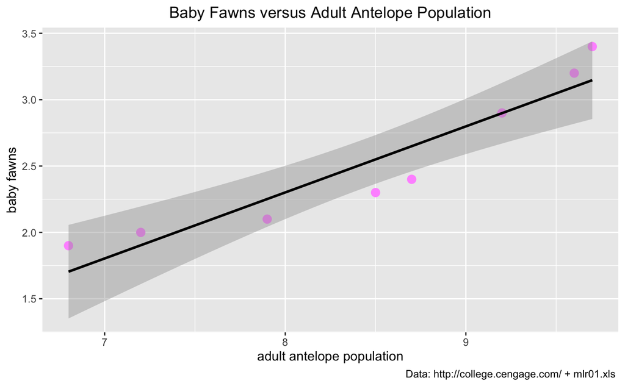

```r
#Baby Fawns versus Adult Antelope Population

  theme <-theme(plot.title = element_text(hjust = 0.5),axis.title = element_text())
  g1 <- ggplot(mlrdf,aes(x=antelope,y=fawn))+geom_point(aes(),size = 3,color="#FF99FF") + geom_smooth(method = "lm",color="black")
  g1 + labs(x = "adult antelope population", y = "baby fawns",
            title = "Baby Fawns versus Adult Antelope Population",
            caption = "Data: http://college.cengage.com/ + mlr01.xls ") + theme
install.packages(pkgs = c("gdata", "RCurl", "ggplot2", "ggcorrplot", "reshape2", "ggeasy", "viridis", "viridisLite"), repos = "http://cran.us.r-project.org")
```